# Reproducible Research: Peer Assessment 1

Emily Kubicek

12/9/2017

*“This assignment makes use of data from a personal activity monitoring device. This device collects data at 5 minute intervals through out the day. The data consists of two months of data from an anonymous individual collected during the months of October and November, 2012 and include the number of steps taken in 5 minute intervals each day.”*

Below are varying analyses conducted on the data starting with loading the data into R.

## Loading and preprocessing the data

#### 1. Load the data

#### 2. Process/transform the data

```r
library(knitr)
setwd("~/Desktop/Coursera/ReproducibleResearch")
data<-read.csv("activity.csv")
data2<- na.omit(data)
library(dplyr)
data3<-tbl_df(data2)
```

## What is mean total number of steps taken per day?

#### 1. Make a histogram of the total number of steps taken each day

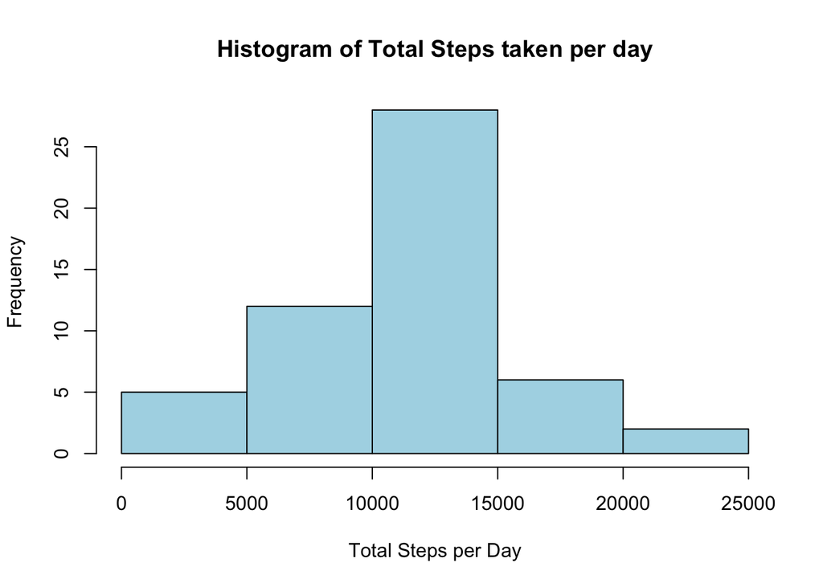

```r
library(ggplot2)
teststeps <- tapply(data3$steps, data3$date, sum)
hist(teststeps, col = "lightblue", xlab = "Total Steps per Day", ylab = "Frequency",
     main = "Histogram of Total Steps taken per day")
```

```r
date_median<-aggregate(data3["steps"], by=data3["date"], median)
date_mean<-aggregate(data3["steps"], by=data3["date"], mean)
dmm<-inner_join(date_median, date_mean, by = "date")
names(dmm)[2:3] <- c("median","mean")
print(dmm)
```

```
##          date median       mean
## 1  2012-10-02      0  0.4375000
## 2  2012-10-03      0 39.4166667
## 3  2012-10-04      0 42.0694444
## 4  2012-10-05      0 46.1597222
## 5  2012-10-06      0 53.5416667
## 6  2012-10-07      0 38.2465278
## 7  2012-10-09      0 44.4826389
## 8  2012-10-10      0 34.3750000
## 9  2012-10-11      0 35.7777778
## 10 2012-10-12      0 60.3541667
## 11 2012-10-13      0 43.1458333
## 12 2012-10-14      0 52.4236111
## 13 2012-10-15      0 35.2048611
## 14 2012-10-16      0 52.3750000
```

[output cut: 39 more lines]

## What is the average daily activity pattern?

#### 1. Make a time series plot (i.e. type = “l”) of the 5-minute interval (x-axis) and the average number of steps taken, averaged across all days (y-axis)

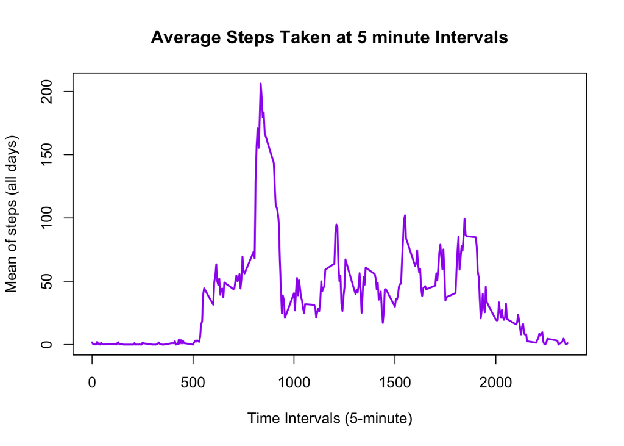

```r
mean_steps <- tapply(data3$steps, data3$interval, mean, na.rm = TRUE)
plot(row.names(mean_steps), mean_steps, type = "l", xlab = "Time Intervals (5-minute)",
     ylab = "Mean of steps (all days)",
     main = "Average Steps Taken at 5 minute Intervals",
     col = "purple", lwd=2)
```

#### 2. Which 5-minute interval, on average across all the days in the dataset, contains the maximum number of steps?

```r
whichmax <- which.max(mean_steps)
maxsteps <- names(whichmax)
print("The interval with the highest number of steps is 835")
```

```
## [1] "The interval with the highest number of steps is 835"
```

## Input missing values

#### 1. Calculate and report the total number of missing values in the data set.

```r
sum(is.na(data))
```

```
## [1] 2304
```

#### 2. Devise a strategy for filling in all of the missing values in the dataset.

#### 3. Create a new dataset that is equal to the original data set but with the missing values filled in.

```r
mean_steps <- tapply(data3$steps, data3$interval, mean, na.rm = TRUE)
head(data)
```

```
##   steps       date interval
## 1    NA 2012-10-01        0
## 2    NA 2012-10-01        5
## 3    NA 2012-10-01       10
## 4    NA 2012-10-01       15
## 5    NA 2012-10-01       20
## 6    NA 2012-10-01       25
```

```r
data[is.na(data)] <- mean_steps
newdata<- data
data<-read.csv("activity.csv")
head(newdata)
```

```
##       steps       date interval
## 1 1.7169811 2012-10-01        0
## 2 0.3396226 2012-10-01        5
## 3 0.1320755 2012-10-01       10
## 4 0.1509434 2012-10-01       15
## 5 0.0754717 2012-10-01       20
## 6 2.0943396 2012-10-01       25
```

#### 4a. Make a histogram of the total number of steps taken each day

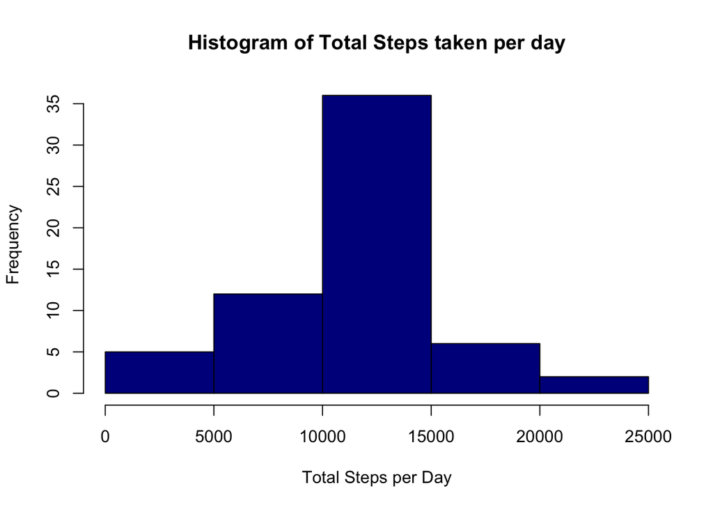

```r
nonas_teststeps <- tapply(newdata$steps, newdata$date, sum)
hist(nonas_teststeps, col = "darkblue", xlab = "Total Steps per Day", ylab = "Frequency",
     main = "Histogram of Total Steps taken per day")
```

```r
nonas_date_median<-aggregate(newdata["steps"], by=newdata["date"], median)
nonas_date_mean<-aggregate(newdata["steps"], by=newdata["date"], mean)
nonas_dmm<-inner_join(date_median, date_mean, by = "date")
names(nonas_dmm)[2:3] <- c("median","mean")
print(nonas_dmm)
```

```
##          date median       mean
## 1  2012-10-02      0  0.4375000
## 2  2012-10-03      0 39.4166667
## 3  2012-10-04      0 42.0694444
## 4  2012-10-05      0 46.1597222
## 5  2012-10-06      0 53.5416667
## 6  2012-10-07      0 38.2465278
## 7  2012-10-09      0 44.4826389
## 8  2012-10-10      0 34.3750000
## 9  2012-10-11      0 35.7777778
## 10 2012-10-12      0 60.3541667
## 11 2012-10-13      0 43.1458333
## 12 2012-10-14      0 52.4236111
## 13 2012-10-15      0 35.2048611
## 14 2012-10-16      0 52.3750000
```

[output cut: 39 more lines]

## Are there differences in activity patterns between weekdays and weekends?

#### 1. Create a new factor variable in the dataset with two levels – “weekday” and “weekend” indicating whether a given date is a weekday or weekend day.

```r
library(dplyr)
library(lubridate)
testdata2 <- data3
# testdata2<-mutate(data3, day = weekdays(data3$date))

testdata2$date<-as.Date(data3$date)
testdata2$Weekend <- weekdays(testdata2$date)
testdata2$Weekend <- grepl("S.+",testdata2$Weekend)


testdata2$date <- as.Date(testdata2$date)
weekdays1 <- c('Monday', 'Tuesday', 'Wednesday', 'Thursday', 'Friday')
testdata2$day <- factor((weekdays(testdata2$date) %in% weekdays1),
                   levels=c(FALSE, TRUE), labels=c('weekend', 'weekday'))
testdata2
```

```
## # A tibble: 15,264 x 5
##    steps       date interval Weekend     day
##  * <int>     <date>    <int>   <lgl>  <fctr>
##  1     0 2012-10-02        0   FALSE weekday
##  2     0 2012-10-02        5   FALSE weekday
##  3     0 2012-10-02       10   FALSE weekday
##  4     0 2012-10-02       15   FALSE weekday
##  5     0 2012-10-02       20   FALSE weekday
##  6     0 2012-10-02       25   FALSE weekday
##  7     0 2012-10-02       30   FALSE weekday
##  8     0 2012-10-02       35   FALSE weekday
##  9     0 2012-10-02       40   FALSE weekday
## 10     0 2012-10-02       45   FALSE weekday
## # ... with 15,254 more rows
```

#### 2. Make a panel plot containing a time series plot (i.e. type = “l”) of the 5-minute interval (x-axis) and the average number of steps taken, averaged across all weekday days or weekend days (y-axis).

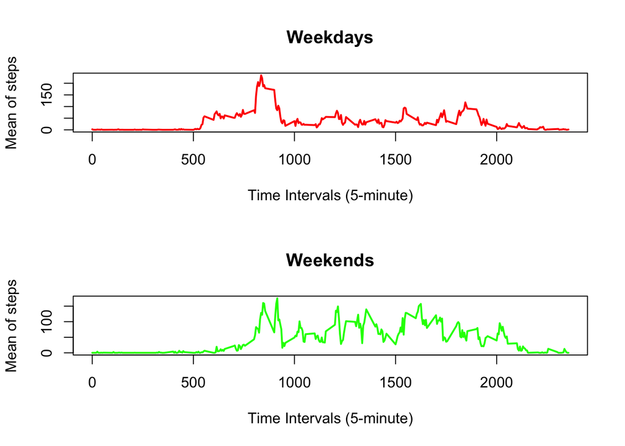

```r
wdaydata<-subset(testdata2, testdata2$day=="weekday")
wdaymean<-tapply(wdaydata$steps, wdaydata$interval, mean, na.rm = TRUE)

wenddata<-subset(testdata2, testdata2$day=="weekend")
wendmean<-tapply(wenddata$steps, wenddata$interval, mean, na.rm = TRUE)


par(mfrow=c(2,1))
plot(names(wdaymean),wdaymean, type = "l",
     xlab = "Time Intervals (5-minute)",
     ylab = "Mean of steps",
     main = "Weekdays",
     col = "red", lwd=2)

plot(names(wendmean),wendmean, type = "l",
     xlab = "Time Intervals (5-minute)",
     ylab = "Mean of steps",
     main = "Weekends",
     col = "green", lwd=2)
```